# Problem Set 2

MGSC 310, Fall 2019, Professor Hersh

Elmer Camargo + Nick Trella

## Libraries Needed

```r
library("tidyverse")
library("ggplot2")
```

## Question 1 ISLR Ch.2 Q.2

A. Regression. n(sample) = whatever subset we pick, p(predictors) = the vars

B. Classification. n = 20 similair products, p = success, failure, price, mark budget, comp price, and 10 other vars

C. Regression because output is expected to be a percentage (aka continuous data) Prediction because we are forcasting future percentage change (n = 52, p = % change in [USD/Euro, US Market, British Market, German Market])

## Question 2 ISLR Ch.2 Q.4

1. Classifying faces on images, Response: yes or no, Predictors: nose, eyes, jaw, etc… Applicational Goal: Predictive because objects on the images are being categorized

Classifying whether or not to give someone 1 of 3 loan, Response: small, medium, large  
Predictors: income, networth, credit history, etc… Applicational Goal: Prediction because output is being categorized into 3 types of loans

Classifying whether someone is a male or female based on previous purchases Response: male or female  
Predictors: types of purchases, stores of purchases Applicational Goal: Inference because you are exploring the relationship of previous purchases

2. Using a regression model to examine the relationship of marijuana dispensaries and crime in a location Response: Reported crimes in a given location Predictors: Marijuana dispensary locations, historical crime reports in locations Applicational Goal: Inference because you are exploring the relationship between crime and marijuana dispensary within a specified location

Using a regression model to predict a sports teams number of points in a game Response: Points in a game Predictors: Individual player points per game average, defensive stats of the oponent Applicational Goal: Predictive because you are estimating

Using a regression model to predict percent change in a stock Response: Predicted percent change stock Predictors: Previous percent change of stock, media coverage Applicational Goal: Predictive because you are estimating a future variable

3. Using cluster analysis to group businesses together by what they sell Using cluster analysis to group people by income Using cluster analysis to group people interests/facebook likes

## Question 3a-b Plotting IMDB’s Top 5000 Movies

```r
movies <-read.csv("data/movie_metadata.csv")

movies <- movies %>% filter(budget<4e+08) #get rid of anomolies

movies <- movies %>% mutate(genre_main = unlist(map(strsplit(as.character(movies$genres),
"\\|"), 1)), grossM = gross/1e+06,
             budgetM = budget/1e+06)

movies <- movies %>% mutate(genre_main = factor(genre_main)%>%
                            fct_drop())
```

## Question 3c Profit and ROI

```r
movies <- movies %>%
  mutate(profitM = grossM - budgetM,
         ROI = profitM / budgetM)
```

## Question 3d Average ROI Plot

```r
sum(is.na(movies$ROI))
movies <- movies %>% drop_na(ROI) #omits NA values in a column
sum(is.na(movies$ROI))

cat('average ROI is', mean(movies$ROI))

hgp1<-ggplot(movies, aes(x=ROI)) +
  geom_histogram(color="black", fill="white", binwidth = 500)
```

[output not shown]

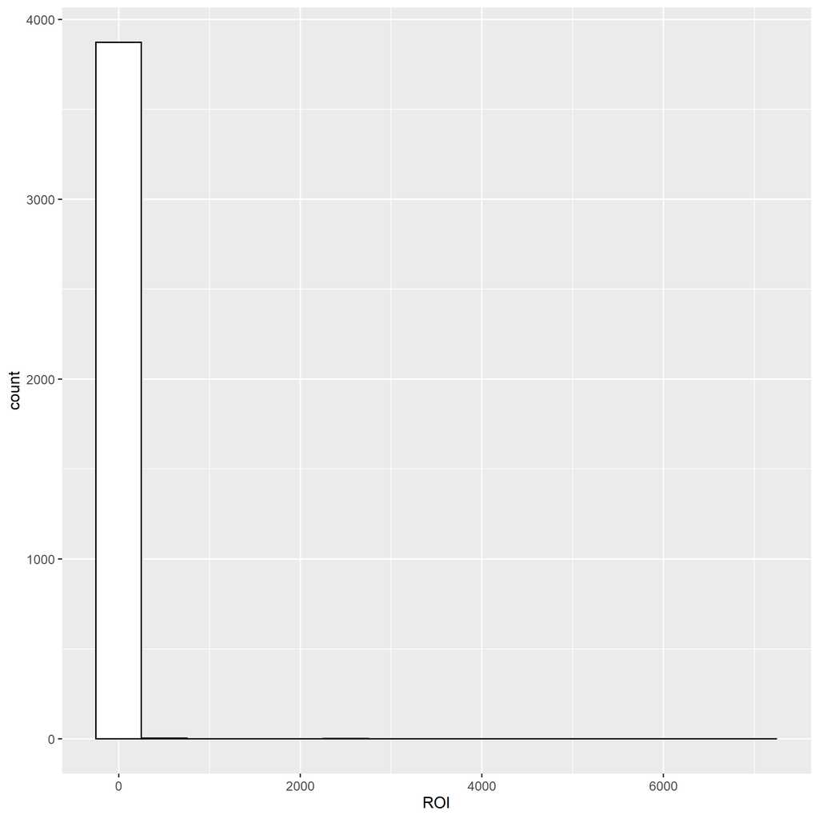

## Question 3e Outliers and Filtering

```r
count(movies, vars = ROI > 10)

movies_filt <- movies %>% filter(ROI < 10) #we want/keep everything < 10

count(movies_filt, vars = ROI > 10)

hp2 <- ggplot(data = movies_filt, aes(ROI))+
  geom_histogram(color="black", fill="white", binwidth = 1)
```

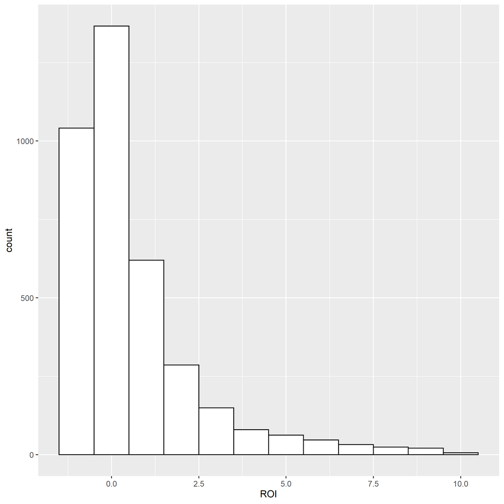

## Question 3f Grouping and Summarizing

```r
average_roi_bycat <- movies_filt %>%
  group_by(genre_main) %>%
  summarize(mean(ROI))

average_roi_bycat

cat("Top 3 Genres: Musical, Western, and Thriller")
```

## Question 3g

```r
meanROI <- average_roi_bycat$`mean(ROI)`
genre <- average_roi_bycat$genre_main

sp1 <- ggplot( data = average_roi_bycat)+
  geom_point(mapping = aes(x = genre, y = meanROI)) +
  labs(x= "Genre",
       y= "Average(ROI)",
       title= "Average ROI by Genre")
```

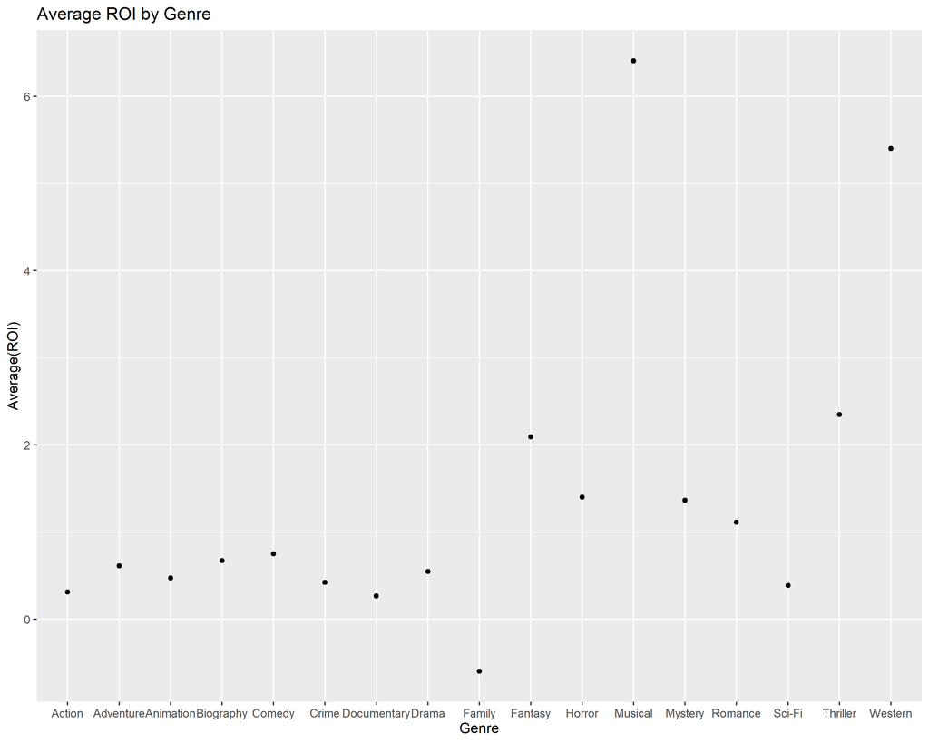

## Question 3h

```r
test3 <- group_by(movies_filt,actor_1_name)

df2 <- summarise(test3,mean(ROI),mean(profitM),num_films = n())
x2 <- df2$`mean(ROI)`
df2 <- df2 %>% arrange(desc(x2))


df2 <- df2 %>% slice(1:20)

df2
```

[output not shown]

## Question 3i

```r
df3 <- summarise(test3,mean(ROI))
y3 <- df3$actor_1_name
x3 <- df3$`mean(ROI)`
df3 <- df3 %>% arrange(desc(x3))
df3 <- df3 %>% slice(1:30)
y3 <- df3$actor_1_name
x3 <- df3$`mean(ROI)`
df3

sp2 <- ggplot(df3 = df3 %>% top_n(30, wt = x3),
              mapping = aes(x = x3, y = reorder(y3, x3)))+
              geom_point()
```

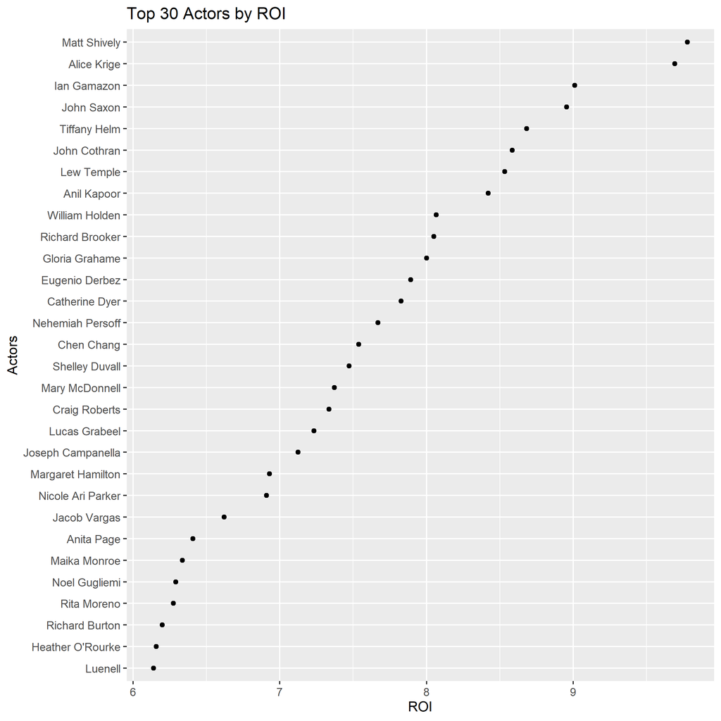

## Question 3j

```r
df4 <- summarise(test3,mean(ROI))
y4 <- df4$actor_1_name
x4 <- df4$`mean(ROI)`
df4 <- df4 %>% arrange((x4))
df4 <- df4 %>% slice(30:1)
y4 <- df4$actor_1_name
x4 <- df4$`mean(ROI)`

sp3 <- ggplot(df4 = df4 %>% top_n(30, wt = x4),
              mapping = aes(x = x4, y = reorder(y4, x4)))+
              geom_point()
```

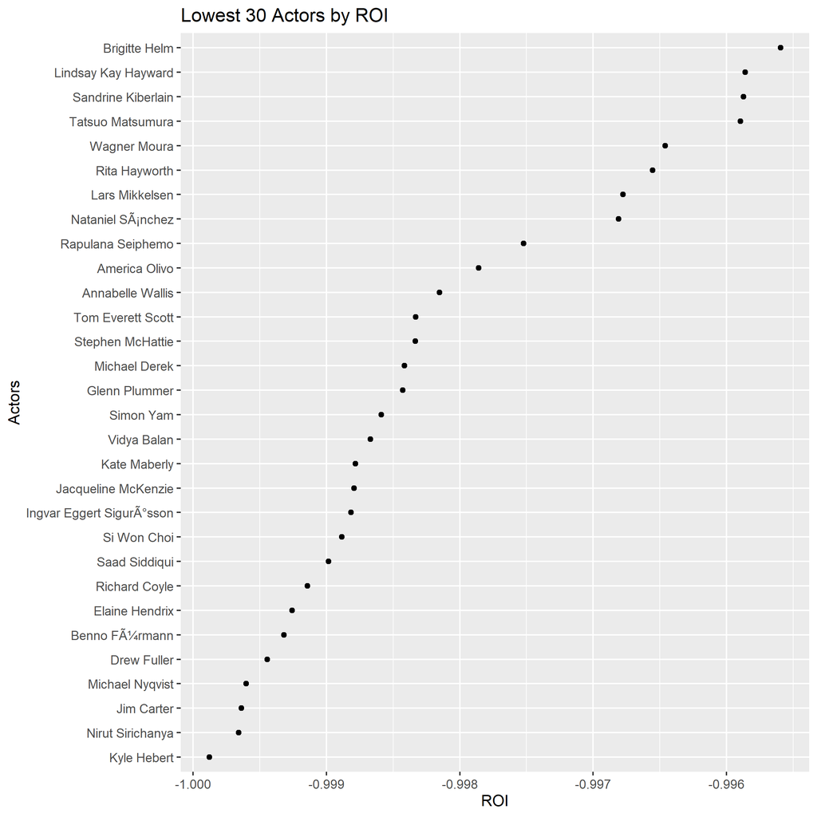

scatterplot 3